# IC50

# 实验部分 - CCK8法

## 细胞培养

取出冻存的MyC-CaP细胞，迅速放入 37℃水浴中解冻，待细胞悬液完全融化后，转移至离心管中，加入适量的培养基，离心去除冻存液。 将细胞接种于T25培养瓶中，加入5ml的DMEM，置于 37℃、5% CO₂的细胞培养箱中培养

## 细胞计数

从培养瓶中取出长满一瓶T25的MyC-CaP细胞，加入500μL胰酶消化3min，加入1ml完全培养液终止消化，制成细胞悬液

将细胞悬液转移至离心管中，以 1000 rpm 的转速离心 3分钟，弃去上清液

加入1ml完全培养液重悬细胞，取250μL悬液加入250μL培养基中（将悬液稀释2倍）

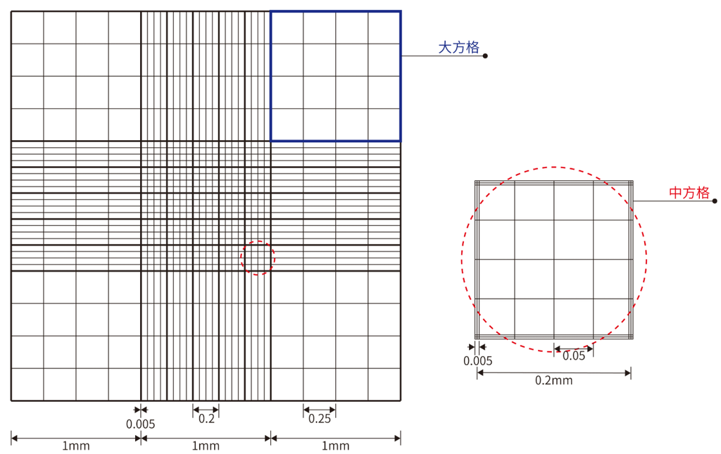

用酒精清洗细胞计数板，用纸巾擦干，在上下室中沿盖玻片外侧分别加入10μL混匀后的悬液，计数得到4个大方格计数平均值为200，计算得细胞量为200万/ml，乘以稀释倍数二倍得原来悬液细胞浓度为400万/ml（如果计数的是较小的方格，则乘以16）

## 铺板

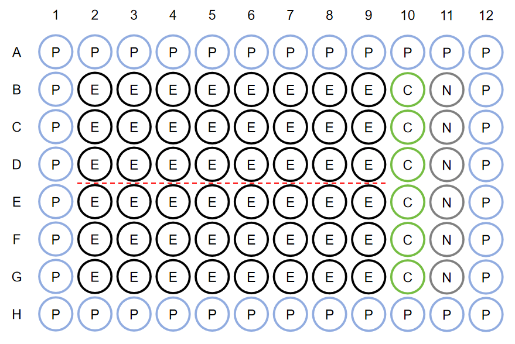

96孔板四周加一圈pbs，每孔200μL

设一组空白对照在11B-G，加DMEM培养基100μL

一组正常对照在第10B-G排，每孔100μL 2000细胞

一共需要六十个孔加2000细胞，可以按照七十个孔计算留有余量，共14万细胞，14/400 =0.035，共需35μL原细胞悬液，先量取7mL DMEM培养基，置于无菌离心管中，随后加入35 μL原细胞悬液混匀即可，此时100μL包含2000细胞

将96孔板置于 37℃、5% CO₂的细胞培养箱中培养24小时

## 加药

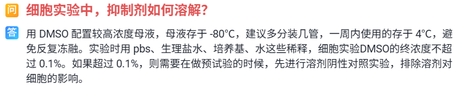

在设计初始浓度时，可以先在[Genomics of Drug Sensitivity in Cancer](https://www.cancerrxgene.org/)或[陶术](https://www.tsbiochem.com/)两个网站检索所测试剂对于其他细胞系的IC50值以供参考

本次初始浓度设置为40nM，则需配置40mM的母液

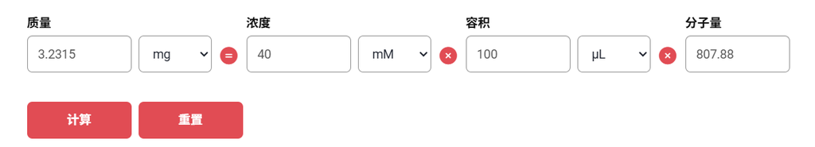

称取得4.2mg多西他赛，等比例加入130μL DMSO溶解配制40mM的母液

将0.6μL母液加入600μL DMSO中混匀后，加入第一组三个孔，每孔100μL，之后加入300μL DMSO稀释后加入第二组孔，以此类推

剩余的母液分装多管放入-80℃中保存，避免反复冻融

## 检测

每孔加入10μL CCK8，放入37℃、5% CO₂的细胞培养箱中培养1小时后检测一次，间隔一小时检测第二次

# 计算IC50

## 数据处理 - Excel

| 吸光值 | 1 | 2 | 3 | 4 | 5 | 6 | 7 | 8 | 9 | 10 | 11 | 12 |
| --- | --- | --- | --- | --- | --- | --- | --- | --- | --- | --- | --- | --- |
| A | 0.1028 | 0.1281 | 0.1210 | 0.1185 | 0.1314 | 0.1253 | 0.1510 | 0.1518 | 0.1708 | 0.1384 | 0.1813 | 0.1579 |
| B | 0.0747 | 0.3547 | 0.5619 | 0.7312 | 0.6609 | 0.6565 | 0.6835 | 0.6026 | 0.6367 | 0.7852 | 0.3551 | 0.0419 |
| C | 0.0650 | 0.3807 | 0.5432 | 0.6240 | 0.6718 | 0.6872 | 0.7086 | 0.7477 | 0.7452 | 0.8326 | 0.3316 | 0.1706 |
| D | 0.0623 | 0.3650 | 0.5240 | 0.6958 | 0.6406 | 0.7128 | 0.7011 | 0.6988 | 0.8104 | 0.7320 | 0.3141 | 0.1558 |
| E | 0.0691 | 0.7140 | 0.3525 | 0.9071 | 1.1279 | 0.9811 | 1.1173 | 1.1874 | 1.1849 | 1.3627 | 0.3043 | 0.1567 |
| F | 0.0645 | 0.5688 | 0.3212 | 0.9143 | 1.0213 | 1.1891 | 1.1887 | 1.0849 | 1.1104 | 1.4242 | 0.3011 | 0.1559 |
| G | 0.0656 | 0.6583 | 0.4304 | 0.8641 | 1.0728 | 1.0470 | 1.1440 | 1.1531 | 1.2780 | 1.3244 | 0.2912 | 0.1408 |
| H | 0.0782 | 0.0707 | 0.0604 | 0.0603 | 0.0592 | 0.0774 | 0.0739 | 0.0737 | 0.0832 | 0.0743 | 0.1075 | 0.1584 |

首先计算背景孔即一圈只加PBS孔的平均吸光值M<sub>PBS</sub>，之后用空白对照组，正常对照组和实验组的数据分别减去M<sub>PBS</sub>得到校正值，后续使用校正值进行计算

计算出空白对照和正常对照的均值分别为M<sub>空白</sub>和M<sub>正常</sub>

之后对于每一个实验组的数据A，按照公式

$$\text{细胞活率（%）} =
\frac{A-M_{空白}}{M_{正常}-M_{空白}} \times 100$$
计算得到每个孔对应的细胞活率

之后分别计算每组的均值M，标准差SD和重复数N

| nM | 40 | 20 | 10 | 5 | 2.5 | 1.25 | 0.625 | 0.3125 | 0.15625 | 0.078125 | 0.0390625 | 0.01953125 | 0.009765625 | 0.004882813 | 0.002441406 | 0.001220703 | 0.000610352 | 0.000305176 |
| --- | --- | --- | --- | --- | --- | --- | --- | --- | --- | --- | --- | --- | --- | --- | --- | --- | --- | --- |
| M | 4.80 | 21.51 | 34.85 | 32.40 | 35.03 | 36.19 | 34.79 | 39.32 | 44.30 | 31.38 | 4.91 | 54.92 | 71.88 | 71.73 | 79.09 | 78.31 | 82.99 | 100.00 |
| SD | 1.24 | 1.80 | 5.18 | 1.50 | 2.67 | 1.22 | 7.00 | 8.32 | 4.77 | 6.95 | 5.33 | 2.57 | 5.06 | 10.08 | 3.42 | 4.95 | 7.97 | 4.78 |
| N | 3 | 3 | 3 | 3 | 3 | 3 | 3 | 3 | 3 | 3 | 3 | 3 | 3 | 3 | 3 | 3 | 3 | 3 |

计算浓度对应的log10并转置数据

[output not shown]

## 作图并得出IC50 - GraphPad

[figure not shown]

打开GraphPad创立XY表，X轴选择数字，Y轴选择已计算好标准差，之后将前面转置好的数据复制进GraphPad

[figure not shown]

点击Analyze，选择非线性回归

[figure not shown]

选择Dose-response-Inhibition下面的log(inhibitor) vs. normalized response – Variable slope，即可得到对应的IC50